# SpaTalk tutorial (single-cell ST data)

Xin Shao

2022-04-06

## **Main**

After pre-processing, we create a SpaTalk object with st_data and st_meta for single-cell ST data by setting `if_st_is_sc` and `spot_max_cell` as `TRUE` and `1`

```r
library(SpaTalk)
```

```r
# load starmap data
load(paste0(system.file(package = 'SpaTalk'), "/extdata/starmap_data.rda"))
load(paste0(system.file(package = 'SpaTalk'), "/extdata/starmap_meta.rda"))

# create SpaTalk data
obj <- createSpaTalk(st_data = as.matrix(starmap_data),
                     st_meta = starmap_meta[, -4],
                     species = "Mouse",
                     if_st_is_sc = T,
                     spot_max_cell = 1)
```

## **Cell-type decomposition**

First, we apply NNLM and spatial mapping to reconstruct the ST data at single-cell resolution using `dec_celltype()`. For single-cell ST data with known cell types, you can directly infer cell cell communication skiping deconvolution. Please refer to the [tutorial](https://github.com/ZJUFanLab/SpaTalk/wiki/Directly-infer-cell-cell-communication-skiping-deconvolution)

```r
# decode the cell-type composition
obj <- dec_celltype(object = obj,
                    sc_data = as.matrix(starmap_data),
                    sc_celltype = starmap_meta$celltype)
```

```
## Performing Non-negative regression for each cell
## ***Done***
```

### Use `plot_st_celltype_percent()` to view cell-type percent

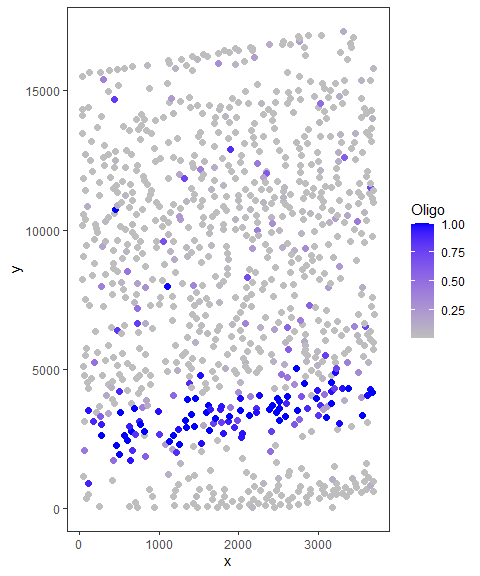

```r
# plot cell-type percent across spatial cells
plot_st_celltype_percent(object = obj, celltype = 'Oligo',size = 2)
```

### Use `plot_st_gene()` to view gene expression

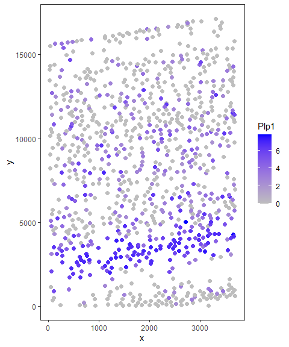

```r
# plot marker gene expression across spatial cells
plot_st_gene(object = obj, gene = 'Plp1',size = 2, if_use_newmeta = F)
```

### Use `plot_st_cor_heatmap()` to view correlation heatmap

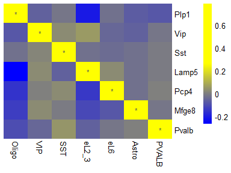

```r
# correlation between marker gene expression and cell type percent across spatial cells
plot_st_cor_heatmap(object = obj,
                    marker_genes = c("Plp1","Vip","Sst","Lamp5","Pcp4","Mfge8","Pvalb"),
                    celltypes = c("Oligo","VIP","SST","eL2_3","eL6","Astro","PVALB"),
                    scale = "none",
                    color_low = 'blue',
                    color_high = 'yellow',
                    color_mid = 'yellow')
```

## **ST at single-cell resolution**

### Use `plot_st_celltype()` to view cell type in space

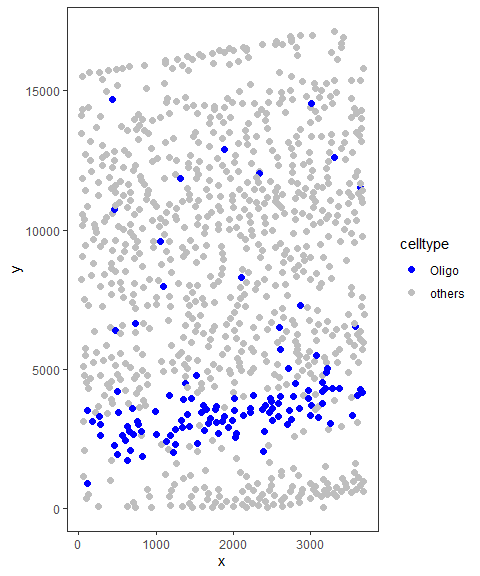

```r
# plot cell type in reconstructed ST atlas
plot_st_celltype(object = obj, celltype = 'Oligo', size = 2)
```

### Use `plot_st_gene()` to view gene expression in space

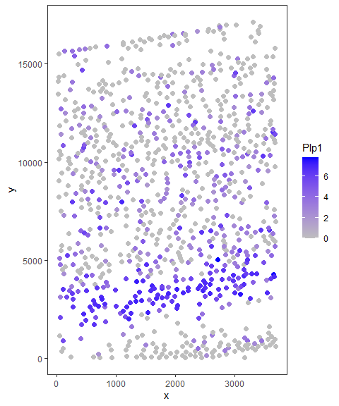

```r
# plot marker gene expression in single-cell ST data
plot_st_gene(object = obj,gene = 'Plp1', if_use_newmeta = T, size = 2)
```

### Use `plot_st_celltype_density()` to view cell-type density in space

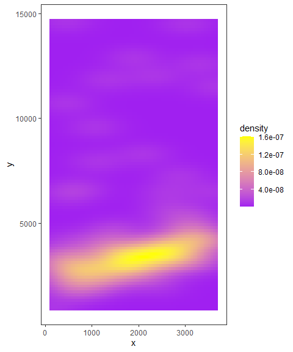

```r
# plot cell-type density in single-cell ST data
plot_st_celltype_density(object = obj,
                         celltype = 'Oligo',
                         type = 'raster',
                         color_low = 'purple',
                         color_high = 'yellow')
```

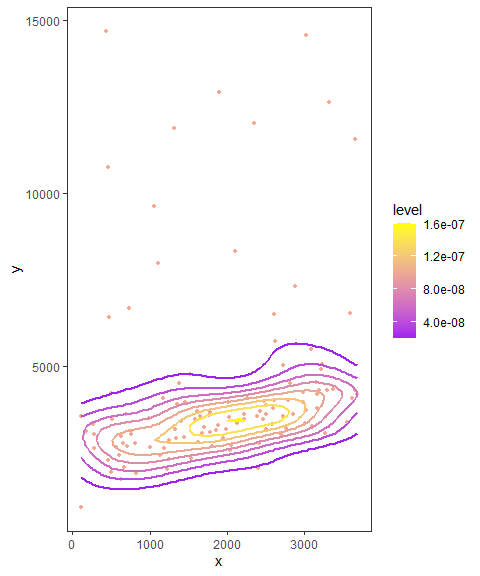

```r
plot_st_celltype_density(object = obj,
                         celltype = 'Oligo',
                         type = 'contour',
                         color_low = 'purple',
                         color_high = 'yellow')
```

### Use `plot_st_celltype_all()` to view all cell types in space

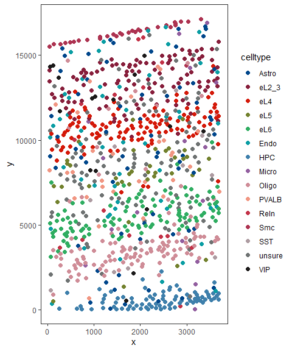

```r
# plot all cell types in single-cell ST data
plot_st_celltype_all(object = obj, size = 2)
```